# Thiamine Exploration

Nicholas Norcia

May 1, 2018

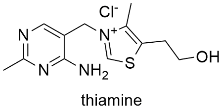

Chemical Structure of Thiamine

# The Data

We will be looking at data of over **7,000 foods**. All recorded by the United States of America Deparment of Agricultural.

Nutrition is the key to living longer. Obesity in America has been a reoccuring problem.

In 2008, the **obesity** rate among Adult Americans was esitmated for men (32.5%) and for women (35.5%).

[figure not shown]

Fat Americans in 2008

We will be reading in the data from the **U.S.D.A** in order to point out healthier foods.

This exact data will be read in below as USDA and food.

USDA National Nutrient Database for Standard Reference

https://ndb.nal.usda.gov/ndb/

https://www.ars.usda.gov/northeast-area/beltsville-md/beltsville-human-nutrition-resear ch-center/nutrient-data-laboratory/docs/sr28-download-files/

“food <- read.csv(”ABBREV.csv“)”

Reading in the data and saving it as the data frame “USDA”.

```r
# Read the csv file
  library(dplyr)
  USDA = read.csv("USDA.csv")
```

We are also reading in the ABBREV.csv and saving it as “food”.

```r
food <- read.csv("ABBREV.csv")
```

This will give us the structure of the dataset food.

```r
# Structure of the dataset
 str(food)
```

```
## 'data.frame':    8790 obs. of  53 variables:
##  $ NDB_No           : int  1001 1002 1003 1004 1005 1006 1007 1008 1009 1010 ...
##  $ Shrt_Desc        : Factor w/ 8787 levels "ABALONE,MIXED SPECIES,RAW",..: 2109 2108 2104 2924 2925 2926 2927 2928 2929 2933 ...
##  $ Water_.g.        : num  15.87 16.72 0.24 42.41 41.11 ...
##  $ Energ_Kcal       : int  717 718 876 353 371 334 300 376 404 387 ...
##  $ Protein_.g.      : num  0.85 0.49 0.28 21.4 23.24 ...
##  $ Lipid_Tot_.g.    : num  81.1 78.3 99.5 28.7 29.7 ...
##  $ Ash_.g.          : num  2.11 1.62 0 5.11 3.18 2.7 3.68 3.28 3.71 3.6 ...
##  $ Carbohydrt_.g.   : num  0.06 2.87 0 2.34 2.79 0.45 0.46 3.06 3.09 4.78 ...
##  $ Fiber_TD_.g.     : num  0 0 0 0 0 0 0 0 0 0 ...
##  $ Sugar_Tot_.g.    : num  0.06 0.06 0 0.5 0.51 0.45 0.46 NA 0.48 NA ...
##  $ Calcium_.mg.     : int  24 23 4 528 674 184 388 673 710 643 ...
##  $ Iron_.mg.        : num  0.02 0.05 0 0.31 0.43 0.5 0.33 0.64 0.14 0.21 ...
##  $ Magnesium_.mg.   : int  2 1 0 23 24 20 20 22 27 21 ...
##  $ Phosphorus_.mg.  : int  24 24 3 387 451 188 347 490 455 464 ...
```

[output cut: 39 more lines]

There are 8,790 observations of 53 variables.

The first is an inter code number of the specific food.

The second is a Factor with the name and/or description of the food/s.

The remaining variables consist of a combination of numbers and intergers. They are specific measuremnts of certain chemicals found in food e.g. water, iron, protein, calcium, thiamine, etc.

We Will be taking a much closer look at Thiamine.

## Thiamine

Also known as Vitamin B1.

Thiamine or vitamin B1 is a healthy additive found in some common foods.

If a person does not intake the proper amount of Thiamine alot of problems can occur. A thiamin deficiency can result in Beriberi or Wermicke Encephalopathy.  
These disesases effect the cardiovascular or nervous system.

Lack of thiamine can be extremely dangerous.

The function of Thiamine is a coenzyme that is used by the body to metabolize food for energy. Thiamine also maintains proper cardiovascular and nervous system functions.

Alot of thiamine molecules are found in proteins and carbohydrates.

Some countries have written laws to require the addition of thiamine to certain foods(grains).

In the United States you can get a month supply of vitamin B1 for under $25.

This report will focus on *Thiamine*, a chemical compound, but a significant varible in the USDA dataset.

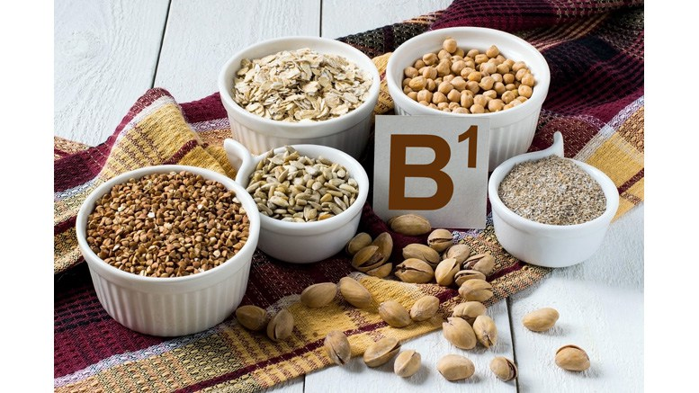

Thaimine Foods

We are going to take a closer look at Thiamine to see if it has any relation to other food characters e.g. Protein or Fat.

```r
# Statistical summary
  summary(food)
```

```
##      NDB_No
##  Min.   : 1001
##  1st Qu.: 9086
##  Median :14428
##  Mean   :15664
##  3rd Qu.:20143
##  Max.   :93600
##
##                                                         Shrt_Desc
##  BEEF,CHUCK,UNDER BLADE CNTR STEAK,BNLESS,DENVER CUT,LN,0" FA:   2
##  OIL,INDUSTRIAL,PALM KERNEL (HYDROGENATED),CONFECTION FAT    :   2
##  POPCORN,OIL-POPPED,LOFAT                                    :   2
##  ABALONE,MIXED SPECIES,RAW                                   :   1
##  ABALONE,MXD SP,CKD,FRIED                                    :   1
##  ABIYUCH,RAW                                                 :   1
##  (Other)                                                     :8781
##    Water_.g.        Energ_Kcal     Protein_.g.    Lipid_Tot_.g.
##  Min.   :  0.00   Min.   :  0.0   Min.   : 0.00   Min.   :  0.00
##  1st Qu.: 29.70   1st Qu.: 91.0   1st Qu.: 2.38   1st Qu.:  0.95
##  Median : 63.08   Median :191.0   Median : 8.00   Median :  5.14
##  Mean   : 54.11   Mean   :226.3   Mean   :11.34   Mean   : 10.55
##  3rd Qu.: 77.96   3rd Qu.:337.0   3rd Qu.:19.88   3rd Qu.: 13.72
##  Max.   :100.00   Max.   :902.0   Max.   :88.32   Max.   :100.00
##  NA's   :1
##     Ash_.g.       Carbohydrt_.g.    Fiber_TD_.g.    Sugar_Tot_.g.
##  Min.   : 0.000   Min.   :  0.00   Min.   : 0.000   Min.   : 0.000
##  1st Qu.: 0.840   1st Qu.:  0.05   1st Qu.: 0.000   1st Qu.: 0.000
##  Median : 1.200   Median :  9.34   Median : 0.700   Median : 1.840
##  Mean   : 1.784   Mean   : 22.13   Mean   : 2.187   Mean   : 8.543
##  3rd Qu.: 2.090   3rd Qu.: 34.91   3rd Qu.: 2.600   3rd Qu.: 9.287
##  Max.   :99.800   Max.   :100.00   Max.   :79.000   Max.   :99.800
##  NA's   :325                       NA's   :594      NA's   :1832
##   Calcium_.mg.       Iron_.mg.      Magnesium_.mg.  Phosphorus_.mg.
##  Min.   :   0.00   Min.   :  0.00   Min.   :  0.0   Min.   :   0.0
##  1st Qu.:  10.00   1st Qu.:  0.54   1st Qu.: 12.0   1st Qu.:  51.0
##  Median :  21.00   Median :  1.38   Median : 21.0   Median : 145.0
##  Mean   :  76.74   Mean   :  2.70   Mean   : 35.3   Mean   : 165.1
##  3rd Qu.:  69.00   3rd Qu.:  2.60   3rd Qu.: 30.0   3rd Qu.: 220.0
##  Max.   :7364.00   Max.   :123.60   Max.   :781.0   Max.   :9918.0
##  NA's   :348       NA's   :144      NA's   :739     NA's   :579
```

[output cut: 81 more lines]

```
##                                                                          :3965
##  1 cup                                                                   : 298
##  1 steak                                                                 : 267
##  1 lb                                                                    : 260
##  1 piece, cooked, excluding refuse (yield from 1 lb raw meat with refuse): 201
##  1 oz                                                                    : 198
##  (Other)                                                                 :3601
##    Refuse_Pct
##  Min.   : 0.000
##  1st Qu.: 0.000
##  Median : 0.000
##  Mean   : 4.964
##  3rd Qu.: 0.000
##  Max.   :81.000
##  NA's   :50
```

A summary of the food data tells us that the average amount of Thiamine .2231mg.

There is only one extreme Thiamine concentration at 23.3750mg.

Let’s find out which food that is. We will use which.max to find the row.

```r
# Finding the index of the food with highest sodium levels
  which.max(food$Thiamin_.mg.)
```

```
## [1] 8735
```

If we use the name function we can see all the variable names.

Shrt_Desc is the food description variable.

We want to find the food name of the 8735 row.

```r
# Get names of variables in the dataset
  names(food)
```

```
##  [1] "NDB_No"            "Shrt_Desc"         "Water_.g."
##  [4] "Energ_Kcal"        "Protein_.g."       "Lipid_Tot_.g."
##  [7] "Ash_.g."           "Carbohydrt_.g."    "Fiber_TD_.g."
## [10] "Sugar_Tot_.g."     "Calcium_.mg."      "Iron_.mg."
## [13] "Magnesium_.mg."    "Phosphorus_.mg."   "Potassium_.mg."
## [16] "Sodium_.mg."       "Zinc_.mg."         "Copper_mg."
## [19] "Manganese_.mg."    "Selenium_.µg."     "Vit_C_.mg."
## [22] "Thiamin_.mg."      "Riboflavin_.mg."   "Niacin_.mg."
## [25] "Panto_Acid_mg."    "Vit_B6_.mg."       "Folate_Tot_.µg."
## [28] "Folic_Acid_.µg."   "Food_Folate_.µg."  "Folate_DFE_.µg."
## [31] "Choline_Tot_..mg." "Vit_B12_.µg."      "Vit_A_IU"
## [34] "Vit_A_RAE"         "Retinol_.µg."      "Alpha_Carot_.µg."
## [37] "Beta_Carot_.µg."   "Beta_Crypt_.µg."   "Lycopene_.µg."
## [40] "Lut.Zea_..µg."     "Vit_E_.mg."        "Vit_D_µg"
## [43] "Vit_D_IU"          "Vit_K_.µg."        "FA_Sat_.g."
## [46] "FA_Mono_.g."       "FA_Poly_.g."       "Cholestrl_.mg."
## [49] "GmWt_1"            "GmWt_Desc1"        "GmWt_2"
## [52] "GmWt_Desc2"        "Refuse_Pct"
```

```r
# Get the name of the food with highest sodium levels
  #USDA$Description[265]
  food$Shrt_Desc[8735]
```

```
## [1] YEAST EXTRACT SPREAD
## 8787 Levels: ABALONE,MIXED SPECIES,RAW ... ZWIEBACK
```

Interesting the food is “YEAST EXTRACT SPREAD”. Nobody would ever eat this.

[figure not shown]

Yeast Extract Spread

This makes sense beacuse Thiamine is normally found in grains or used as a healthy additive.

There must be alot of Thiamine in Yeast.

Let’s take a look at other foods with alot of Thiamine.

```r
# Create a subset of the foods with Thiamine content above 2.5mg
 HighThaimin = subset(food, Thiamin_.mg.>2.5)

# Count the number of rows, or observations
  nrow(HighThaimin)
```

```
## [1] 42
```

There are 42 foods with more than 2.5mg of Thiamine.

```r
# Output names of the foods with high Thiamine content

  HighThaimin$Shrt_Desc
```

```
##  [1] BABYFOOD,CRL,MXD,W/ BANANAS,DRY
##  [2] BABYFOOD,CRL,OATMEAL,W/HONEY,DRY
##  [3] BABYFOOD,CRL,HI PROT,W/APPL&ORANGE,DRY
##  [4] BABYFOOD,CRL,RICE,W/ BANANAS,DRY
##  [5] SOUP,CRM OF VEG,DRY,PDR
##  [6] CEREALS RTE,KELLOGG,KELLOGG'S ALL-BRAN COMPLETE WHEAT FLAKES
##  [7] CEREALS RTE,KELLOGG,KELLOGG'S PRODUCT 19
##  [8] CEREALS RTE,GENERAL MILLS,WHL GRAIN TOTAL
##  [9] CEREALS RTE,GENERAL MILLS,WHEATIES
## [10] CEREALS RTE,RICE,PUFFED,FORT
## [11] CEREALS RTE,WHEAT,PUFFED,FORT
## [12] CEREALS RTE,GENERAL MILLS,TOTAL RAISIN BRAN
## [13] CEREALS RTE,KELLOGG,KELLOGG'S SMART START ANTIOXIDANTS CRL
## [14] CEREALS RTE,RALSTON ENR WHEAT BRAN FLAKES
## [15] CEREALS RTE,RALSTON CORN FLAKES
```

[output cut: 28 more lines]

**Interesting, very interesting.**

Who doesn’t love a box of Raisin Bran Crunch? Thiamine rich people sure do not.

It seems that alot of Thiamine rich foods are Cereals, Baby-Food, Soup, Sesame Flour, Power Bars, Formula Bars, some Beef, and a few others.

We would not really want to eat Baby-Food or Seasame Flour but the others are very interesting.

This makes sense because Thiamine is found in whole grains and some meats but is also used as a healthy dietary additive.

```r
# Summary function over Thiamine vector
  summary(food$Thiamin_.mg.)
```

```
##    Min. 1st Qu.  Median    Mean 3rd Qu.    Max.    NA's
##  0.0000  0.0400  0.0840  0.2231  0.2500 23.3750     634
```

```r
# Standard deviation
  sd(food$Thiamin_.mg., na.rm = TRUE)
```

```
## [1] 0.5237518
```

The **mean** Thiamine is **.2231mg** with a **standard deviation** of **.5238mg.**

### Plots

Let’s plot Thiamin vs Saturated Fat from the food data frame.

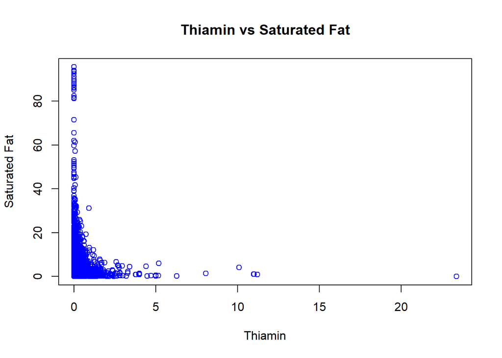

```r
# Add xlabel, ylabel and title
  plot(food$Thiamin_.mg., food$FA_Sat_.g., xlab="Thiamin", ylab = "Saturated Fat", main = "Thiamin vs Saturated Fat", col = "blue")
```

This did not give us much. There is the one “Yease Extract Spread” outlier around 24mg. Everthing else is mostly bunched up.

It seems that saturated fat however has a reverse relationship with Thiamine. When there is more saturated fat there is less Thiamin and vice versa.

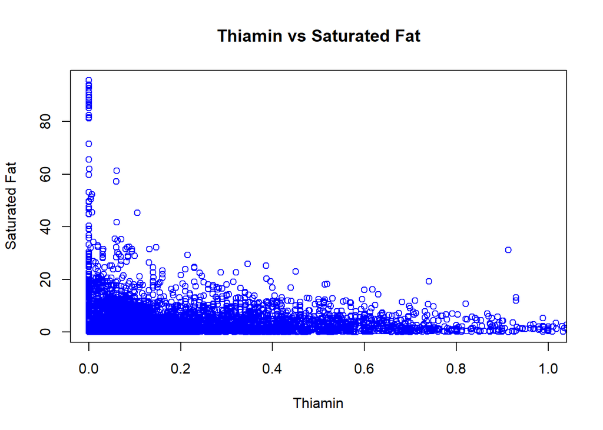

```r
  plot(food$Thiamin_.mg., food$FA_Sat_.g., xlab="Thiamin", ylab = "Saturated Fat", xlim = c(0,1), main = "Thiamin vs Saturated Fat", col = "blue")
```

A closer look at Thiamine vs Saturated Fat. The more Thiamine the less saturated fat it seems.

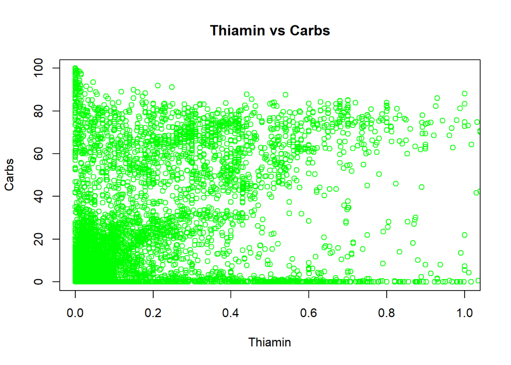

```r
plot(food$Thiamin_.mg., food$Carbohydrt_.g., xlab="Thiamin", ylab = "Carbs", xlim = c(0,1), main = "Thiamin vs Carbs", col = "green")
```

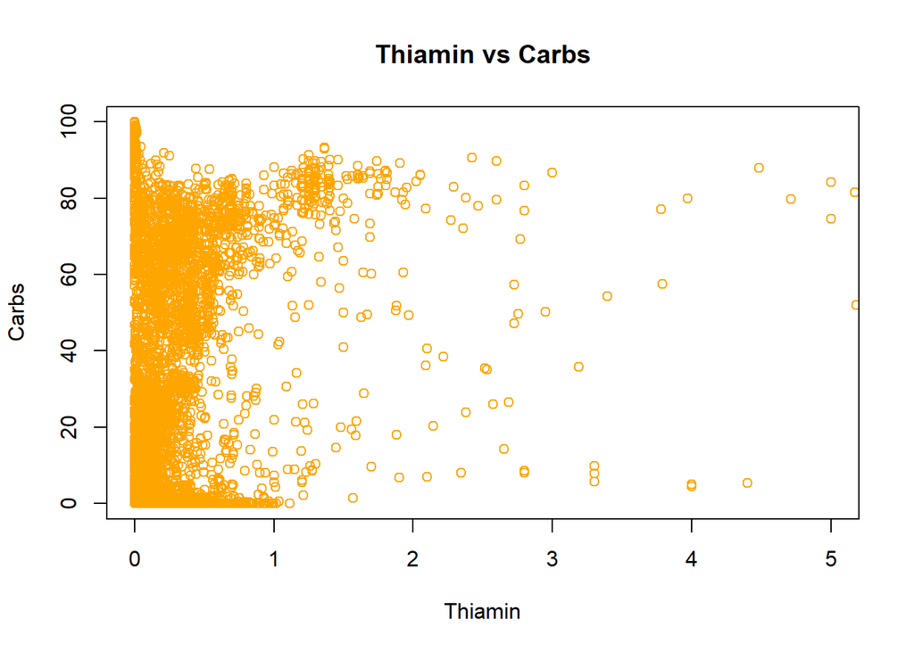

```r
plot(food$Thiamin_.mg., food$Carbohydrt_.g., xlab="Thiamin", ylab = "Carbs", xlim = c(0,5), main = "Thiamin vs Carbs", col = "orange")
```

Without the 0 values Thiamin and Carbs have a somewhat linear relationship. If a food has alot of Thiamine it usually has alot of carbs.

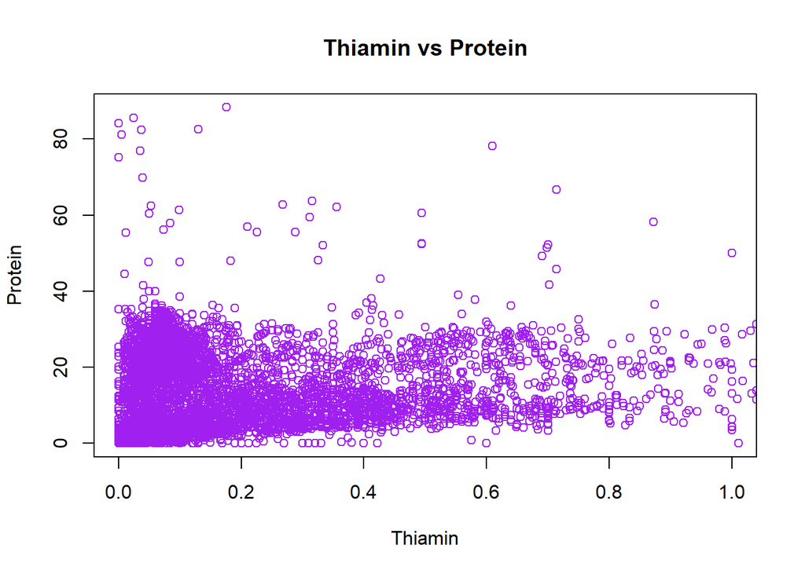

```r
plot(food$Thiamin_.mg., food$Protein_.g., xlab="Thiamin", ylab = "Protein", xlim = c(0,1), main = "Thiamin vs Protein", col = "purple")
```

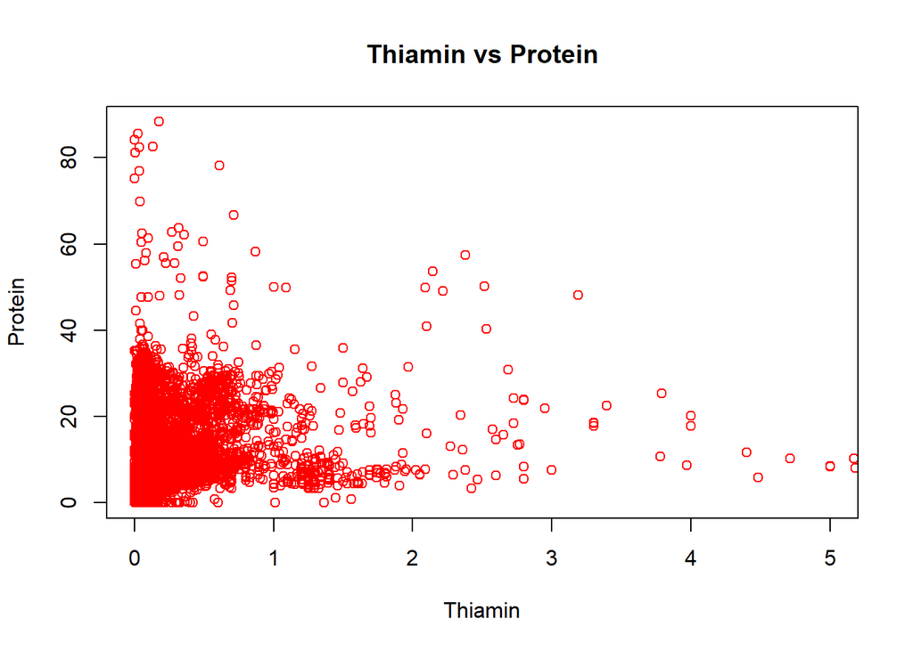

```r
plot(food$Thiamin_.mg., food$Protein_.g., xlab="Thiamin", ylab = "Protein", xlim = c(0,5), main = "Thiamin vs Protein", col = "red")
```

It seemes alot of foods with Thiamine have around 20mg of protein.

### Histogram of Thiamine

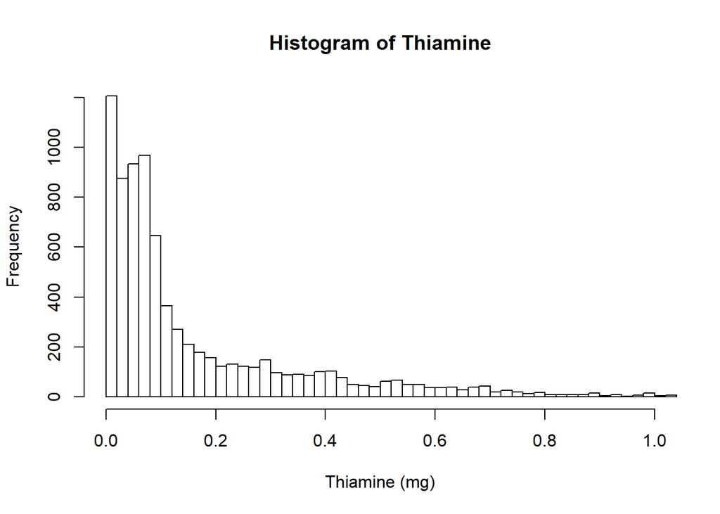

```r
# Breaking of Thiamine histogram
  hist(food$Thiamin_.mg., xlab = "Thiamine (mg)", main = "Histogram of Thiamine", xlim = c(0,1), breaks=1500)
```

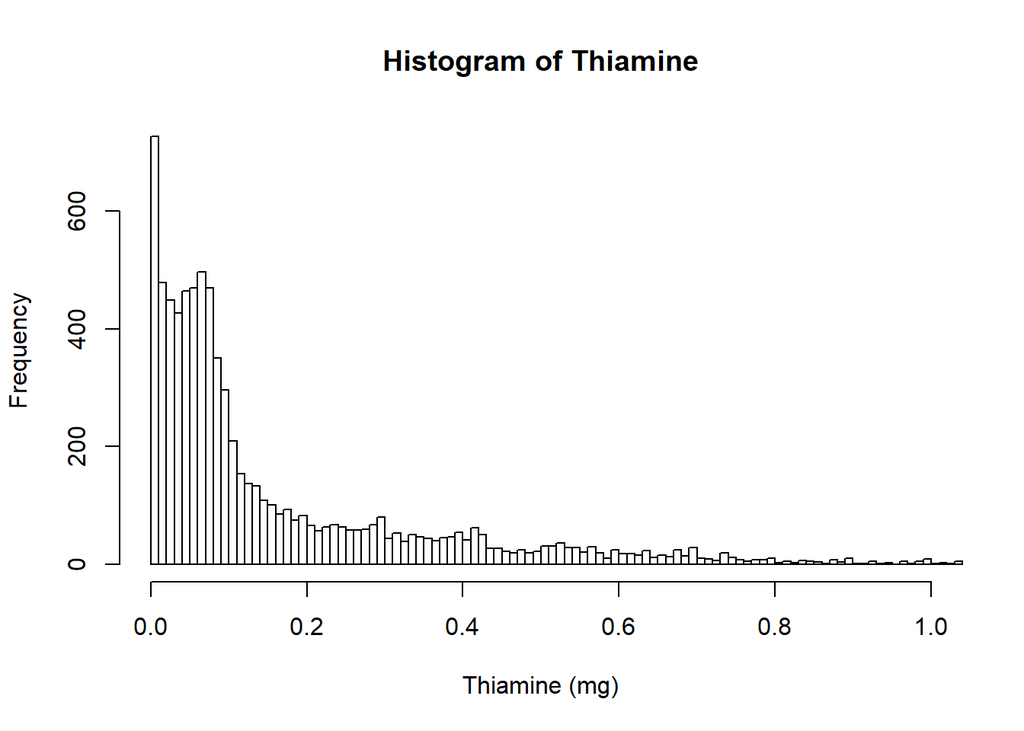

```r
  hist(food$Thiamin_.mg., xlab = "Thiamine (mg)", main = "Histogram of Thiamine", xlim = c(0,1), breaks=2000)
```

Alot of foods have very little Thiamine. There are a couple foods that have a ton of Thiamine like Yeast.

### Boxplot

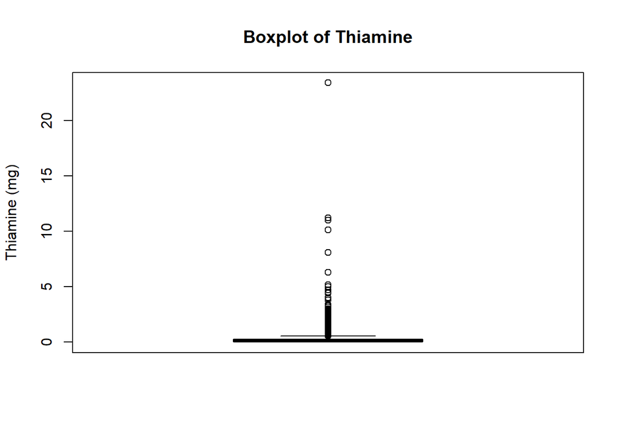

```r
# Boxplots
  boxplot(food$Thiamin_.mg., ylab = "Thiamine (mg)", main = "Boxplot of Thiamine")
```

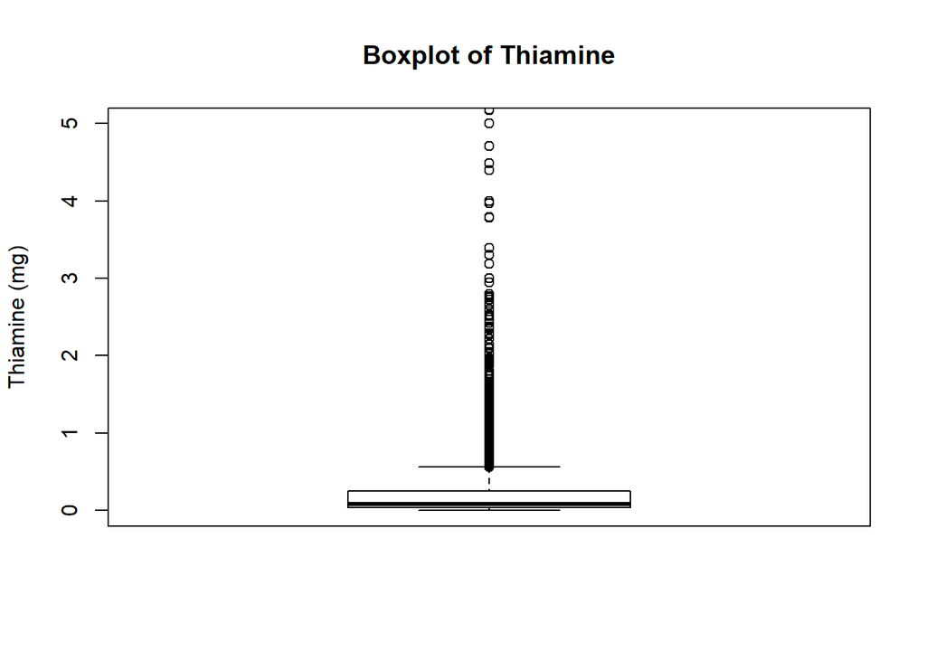

```r
  boxplot(food$Thiamin_.mg., ylab = "Thiamine (mg)", ylim = c(0,5), main = "Boxplot of Thiamine")
```

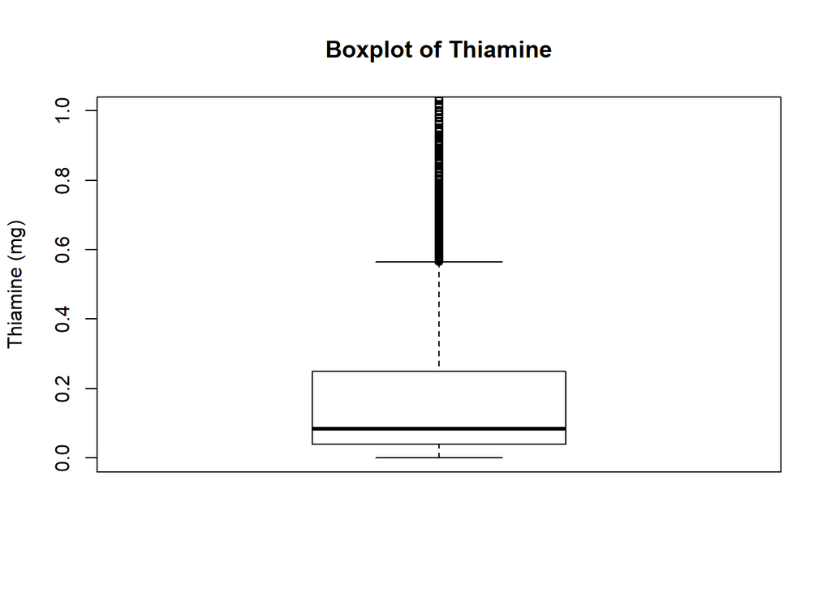

```r
  boxplot(food$Thiamin_.mg., ylab = "Thiamine (mg)", ylim = c(0,1), main = "Boxplot of Thiamine")
```

### Comparing High Values with Thiamine

We want to add a variable to our USDA data frame that takes a value 1 if the food has higher Thiamine than average, and 0 if the food has lower Thiamine than average.

```r
# Creating a variable that takes value 1 if the food has higher Thiamine than average, 0 if else.
  HighThiamine = as.numeric(food$Thiamin_.mg. > mean(food$Thiamin_.mg., na.rm=TRUE))
  str(HighThiamine)
```

```
##  num [1:8790] 0 0 0 0 0 0 0 0 0 0 ...
```

Let’s add some more of these varibles for Carbs, Protein, and Fat.

```r
# Adding the High Thiamine variable to the dataset
  food$HighThiamine = as.numeric(food$Thiamin_.mg. > mean(food$Thiamin_.mg., na.rm=TRUE))
```

```r
# Let's do the same for HighProtein, HigCarbs, HighFat
# I think all will be interesting varibles to consider against
# High Thiamine.
  food$HighCarbs = as.numeric(food$Carbohydrt_.g. > mean(food$Carbohydrt_.g., na.rm=TRUE))
  food$HighProtein = as.numeric(food$Protein_.g. > mean(food$Protein_.g., na.rm=TRUE))
  food$HighFat = as.numeric(food$FA_Sat_.g. > mean(food$FA_Sat_.g., na.rm=TRUE))
```

```r
# How many foods have higher Thiamine level than average?
  table(food$HighThiamine)
```

```
##
##    0    1
## 5944 2212
```

2212 foods have higher than average Thiamine content.

```r
# How many foods have both high Thiamine and high carbs?
  table(food$HighThiamine, food$HighCarbs)
```

```
##
##        0    1
##   0 4757 1187
##   1  685 1527
```

It seems you can get a high dosage of Thiamine in foods with high amounts of carbs.

Which makes sense because Thaimin is normally found in grains.

```r
# Average amount of Thiamine sorted by high and low protein?
  tapply(food$HighThiamine, food$HighProtein, mean, na.rm=TRUE)
```

```
##         0         1
## 0.2614826 0.2843165
```

```r
# Maximum level of Thiamine in foods with high and low carbs?
  tapply(food$Thiamin_.mg., food$HighFat, max, na.rm=TRUE)
```

```
##      0      1
## 23.375 10.100
```

```r
# Using summary function with tapply
  tapply(food$Thiamin_.mg., food$HighFat, summary, na.rm=TRUE)
```

```
## $`0`
##    Min. 1st Qu.  Median    Mean 3rd Qu.    Max.    NA's
##  0.0000  0.0360  0.0790  0.2328  0.2370 23.3750     434
##
## $`1`
##    Min. 1st Qu.  Median    Mean 3rd Qu.    Max.    NA's
##  0.0000  0.0600  0.1060  0.2129  0.2830 10.1000     108
```

There is a higher concentraion of Thiamine .23mg when fat is low then when there is high fat .21mg.

# Conclusion

**Thiamine** is also known as **Vitamin B1**.

Thiamine is a very healthy **dietary addtive**. It is found in **grains**, **protein bars**, and **some meats e.g. bacon**.

There is **more Thiamine** in foods that are **low in fat**, **high in protein**, and **high in carbs**.

I would suggest eating **protein bars** or whole wheat grains like **cereal** for your necessary Thiamine intake.

In order to prevent Thiamine related severe diseases.

**Eat This**

[figure not shown]

Not This

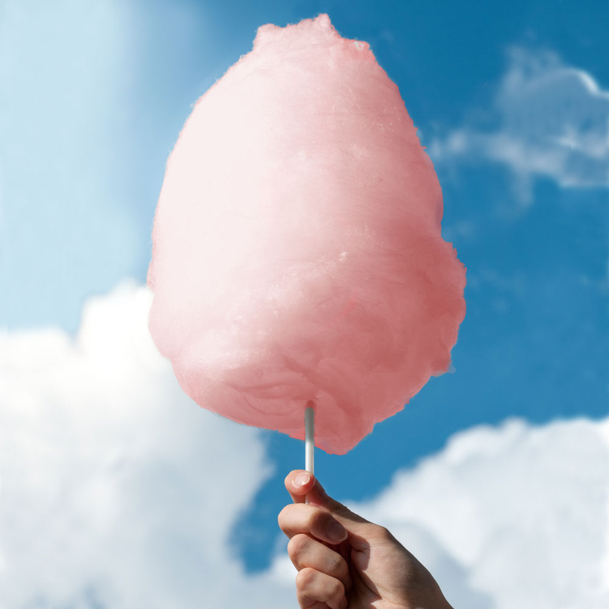